# 2. Bootstrap method

2023-05-16

> [*Back to content page*](https://flatter11.github.io/6040/)

Learning objectives

- Understand the mechanism of bootstrap method
- Generate various statistical estimates using the bootstrap method
- Recognize different types of bootstrap methods

# 1 Bootstrap

Rationale

- As an alternative to asymptotic (large sample) approximation, e.g. Central limit theorem: sample mean approaches a normal distribution and Maximum likelihood estimator (MLE) approaches a normal distribution => When we have a **small sample size, such approximation may not be that accurate**
- Can estimate variance and CI even when formula of distribution is unavailable

Plug-in principle

- Concept: **Plug in data from samples when we don’t have population data**
  - For a parameter $\theta = t(F)$, the plug-in estimate is given by $\hat\theta = t(\hat F)$ where F is the true distribution
  - $\hat F$ give a probability mass of 1/n to each X, assuming we have data X<sub>1</sub>, X<sub>2</sub>, …, X<sub>n</sub>
- Steps:
  - In order to construct CI and p-value for our parameter $\theta$, we need to know the sampling distribution of its estimate $\hat \theta$. If we don’t know the sampling distribution we can instead bootstrap the sample.
  - **Random re-sampling** – We sample with replacement from the original sample. New sample size is same as original sample size. Calculate $\hat \theta$ for the new sample, repeat the process by B times. Distribution of $\hat \theta$ will approximate the sampling distribution.

Example

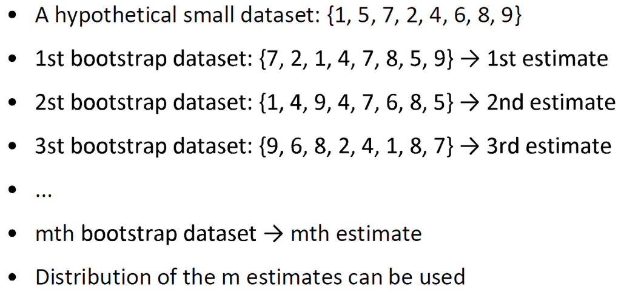

## A. Types of bootstrap

1. Non-parametric bootstrap
   - No distributional assumption for the data
   - Resampling (with replacement) from the **observations**
   - Use new observations to obtain the estimates
2. Residual/semi-parametric bootstrap
   - Fit a (parametric) model and calculate the residuals $\hat \epsilon_i = y_i - \hat y_i$ (observation - prediction)
   - Resampling the **residual** $\epsilon_i^*$ (non-parametric) and **recreate the response** $y_i^* = \hat y_i + \epsilon_i^*$
   - Fit the model using the response $y_i^*$ to obtain the estimates for the parameter of interest
3. Parametric bootstrap
   - First, estimate the distribution of the parameters
   - Resampling (with replacement) the **observations from the model** $y_i^* \sim M_\theta$
   - Estimate the parameters from each bootstrap dataset

### Original result

```r
mvc <- read.csv("Data/mvc.csv")
lm.mvc <- lm(height ~ age, mvc)
summary(lm.mvc)
confint(lm.mvc)[2, ]
# beta = -0.195, s.e. = 0.087, 95% CI = (-0.371, -0.019)
```

### 1) Non-parametric

```r
bootlm <- function (m, original.data){
 beta <- rep (NA, m)#repeat NA by m times
 for (i in 1:m){
  newdata <- original.data[sample(1:41, 41, replace=TRUE), ]##create bootstrap data
  ## by drawing 1-14 lines from original dataset by 41 times with replacement
  b.lm <- lm(height ~ age, data=newdata)
  beta[i] <- coef(b.lm)[2] #store coefficient into beta[i] to get 1000 beta estimate
 }
 return(beta) ##new 1000 beta
}

b.beta <- bootlm(1000, original.data=mvc)
mean(b.beta) # bootstrapped mean of beta
sd(b.beta) # bootstrapped standard error of the estimate of the mean
quantile(b.beta, c(0.025, 0.975)) # 95% CI of mean
## Can see bootstrapped result is consistent with Original result (beta = -0.196, se = 0.08, 95%CI = -0.37, -0.03)
```

```
## [1] -0.1956453
## [1] 0.0891829
##        2.5%       97.5%
## -0.36483407 -0.01614892
```

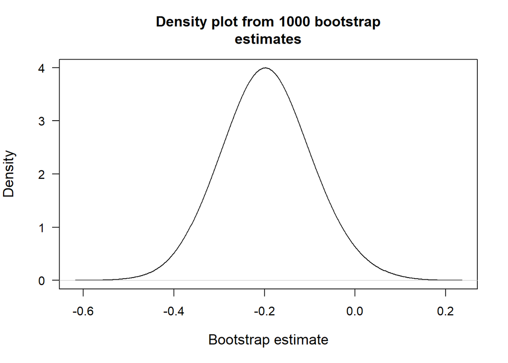

```r
## Density plot
plot(density(b.beta, bw=0.05), main = "Density plot from 1000 bootstrap
estimates", xlab = "Bootstrap estimate", cex.lab=1.2, las=1)
```

### 2) Residual

```r
lm.mvc <- lm(height ~ age, mvc)
mvc$residual <- resid(lm.mvc) #original residual
mvc$height.pred <- predict(lm.mvc) #original prediction
resbootlm <- function(m, original.data) {
  beta <- rep (NA,m)
  for(i in 1:m){
    b.resid <- original.data$residual[sample(1:41, 41, replace=T)] ##new residual
    newdata <- original.data
    newdata$height.b <- newdata$height.pred + b.resid ##new observation (yi*)
    b.lm <- lm(height.b ~ age, newdata)
    beta[i] <- coef(b.lm)[2]
  }
  return(beta) ##new 1000 beta
}

resb.beta <- resbootlm(1000, original.data=mvc)
mean(resb.beta) # residual bootstrapped mean of beta
sd(resb.beta) # residual bootstrapped standard error of the estimate of the mean
quantile(resb.beta, c(0.025, 0.975)) # 95% CI of mean
## Can see bootstrapped result is consistent with original result (beta = -0.192, se = 0.08, 95%CI = -0.35, -0.03)
```

```
## [1] -0.1950328
## [1] 0.08443142
##        2.5%       97.5%
## -0.35897800 -0.02609379
```

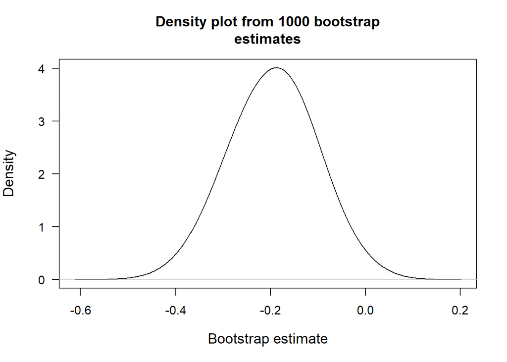

```r
## Density plot
plot(density(resb.beta, bw=0.05), main = "Density plot from 1000 bootstrap
estimates", xlab = "Bootstrap estimate", cex.lab=1.2, las=1)
```

### 3) Parametric

```r
lm.mvc <- lm(height~age, mvc)
parabootlm <- function (m, original.data){
  beta <- rep (NA, m)
  for (i in 1:m){
    newdata <- original.data
    newdata$height.b <- simulate(lm.mvc)$sim_1 ##simulate response based on distribution
    ## from a fitted model (sim_1 to make sure calling correct object)
    b.lm <- lm(height.b ~ age, data=newdata)
    beta[i] <- coef(b.lm)[2]
  }
  return(beta) ##new 1000 beta
}

parab.beta <- parabootlm(1000, original.data=mvc)
mean(parab.beta) # bootstrapped mean of beta
sd(parab.beta) # bootstrapped standard error of the estimate of the mean
quantile(parab.beta, c(0.025, 0.975)) # 95% CI of mean
## Can see bootstrapped result is consistent with original result (beta = -0.194, se = 0.09, 95%CI = -0.36, -0.03)
```

```
## [1] -0.1974048
## [1] 0.09024252
##        2.5%       97.5%
## -0.37676484 -0.02857546
```

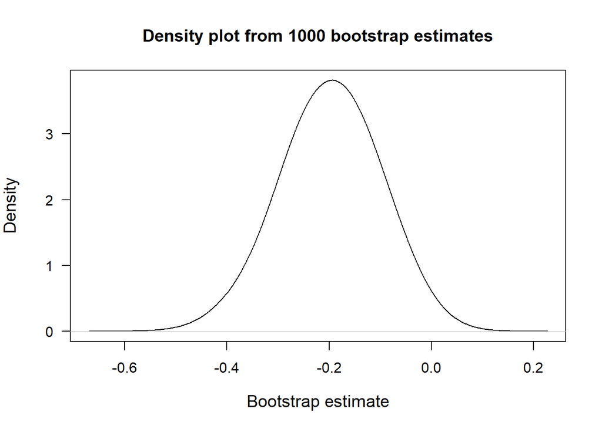

```r
## Density plot
plot(density(parab.beta, bw=0.05), main = "Density plot from 1000 bootstrap estimates", xlab = "Bootstrap estimate", cex.lab=1.2, las=1)
```

## B. Bootstrap CI

1. Normal – Need large sample size or normal assumption $\hat \theta ± t_{1-\alpha 2} se^*(\hat \theta)$
2. Studentized – Extension of the normal bootstrap confidence interval by resampling T* to replace $ t_{1-}$
3. Percentile – Given by $(\hat \theta_{\alpha /2}^*, \hat \theta_{1-\alpha /2}^*)$
4. Bias-corrected and accelerated (BCa) – Shift and rescale the estimate to correct for bias

### A. What is AUROC?

- Area under ROC (receiver operating characteristics) curve
  - Measure of discriminative performance of a model – How accurately does the model distinguish the cases from the controls / the deaths from the survivors / the positives from the negatives
  - If we are only given a subject’s score, how can we use a model to determine whether the subject is a case or not, How should we draw the threshold?
  - **Can calculate sensitivity and specificity for each possible threshold value; the goal is to maximize area under the curve**

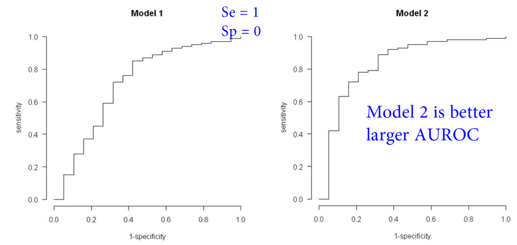

### B. Use ROCR package to determine AUROC

- `prediction(predictions, true values)` to create prediction objects
  - **predictions** = predicted scores/probability being a case
  - **labels** = true values, should be vector of 0s and 1s
- `performance(prediction.object, measure="auc")` to create performance objects
  - **measure** is performance measure, used for evaluation
- `performance.object@y.values[[1]]`

```r
sars <- read.csv("Data/SARS08.csv")
library(ROCR)
sars.glm <- glm(case ~ age + male + fever + sorethroat + cough,data=sars, family=binomial)
sars$pred <- predict(sars.glm, type="response") #prediction probability based on glm model
pred.obj <- prediction(sars$pred, sars$case) ## prediction objects
perf.obj <- performance(pred.obj, measure="auc") ## performance objects
auroc <- perf.obj@y.values[[1]]
auroc
```

```
## [1] 0.7500875
```

### C. Bootstrap CI for AUROC

It is difficult to estimate se and hence CI for AUROC, therefore we need bootstrap to help.

```r
b.auroc <- rep(NA,1000)
for (i in 1:1000){
  sars.new <- sars[sample(1:800, 800, replace=TRUE),] ##re-sample on original data
  b.pred.obj <- prediction(sars.new$pred, sars.new$case)
  b.perf.obj <- performance(b.pred.obj, measure="auc")
  b.auroc[i] <- b.perf.obj@y.values[[1]] ##1000 auroc for each bootstrap sample
}
mean(b.auroc)
quantile(b.auroc, c(0.025, 0.975))
## Can obtain CI now! mean = 0.75, 95%CI = 0.71, 0.79
```

```
## [1] 0.7501569
##      2.5%     97.5%
## 0.7127967 0.7854638
```

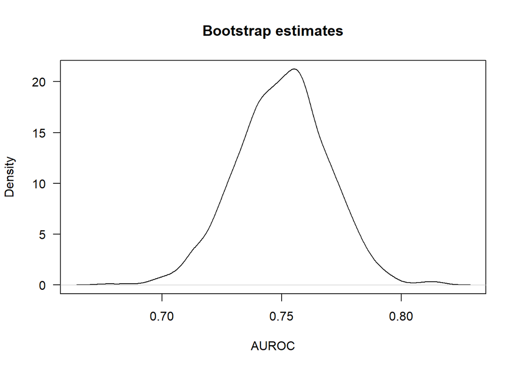

```r
## Density plot
plot(density(b.auroc), las=1, xlab="AUROC", main="Bootstrap estimates")
```

## C. Bootstrap package

- `boot(data, statistic, R)` generate bootstrap samples
  - **data**…dataset
  - **statistic**…function returning the statistic of interest  
    there should be at least two arguments for the function, first: original data; second: indices which specify bootstrap samples
  - **R**…the number of bootstrap replicate
- `boot.ci(boot.out, conf = 0.95, type="all")` construct bootstrap CI
  - **boot.out**…the object of class “boot” with bootstrap replication
  - **conf**…the confidence level for the confidence interval
  - **type**…selects the type of bootstrap confidence intervals, such as “norm”, “stud”, “perc”, “bca”

### Example MVC

```r
## MVC dataset in part A
library(boot)
mvclm.out <- function (data, indices){
  newdata <- data[indices, ] # a way to generate statistic (regression coefficient)
  b.lm <- lm(height ~ age, data=newdata)
  return(coef(b.lm)["age"])
}
mvc.b.out <- boot(data=mvc, statistic=mvclm.out, R=1000)
boot.ci(mvc.b.out)
```

```
## BOOTSTRAP CONFIDENCE INTERVAL CALCULATIONS
## Based on 1000 bootstrap replicates
##
## CALL :
## boot.ci(boot.out = mvc.b.out)
##
## Intervals :
## Level      Normal              Basic
## 95%   (-0.3638, -0.0283 )   (-0.3667, -0.0213 )
##
## Level     Percentile            BCa
## 95%   (-0.3688, -0.0234 )   (-0.3646, -0.0228 )
## Calculations and Intervals on Original Scale
```

### Example AUROC

```r
## AUROC dataset in part B
auroc.b.out <- function (data, indices){
  sars.new <- sars[indices,]
  sars.glm <- glm(case ~ age + male + fever + sorethroat + cough,
  data=sars.new, family=binomial)
  sars.new$pred <- predict(sars.glm, type="response")
  b.pred.obj <- prediction(sars.new$pred, sars.new$case)
  b.perf.obj <- performance(b.pred.obj, measure="auc")
  return(b.perf.obj@y.values[[1]])
}
sars.b.out <- boot(data=sars, statistic=auroc.b.out, R=1000)
boot.ci(sars.b.out)
```

```
## BOOTSTRAP CONFIDENCE INTERVAL CALCULATIONS
## Based on 1000 bootstrap replicates
##
## CALL :
## boot.ci(boot.out = sars.b.out)
##
## Intervals :
## Level      Normal              Basic
## 95%   ( 0.7129,  0.7850 )   ( 0.7142,  0.7855 )
##
## Level     Percentile            BCa
## 95%   ( 0.7147,  0.7860 )   ( 0.7131,  0.7846 )
## Calculations and Intervals on Original Scale
```

Bootstrap review

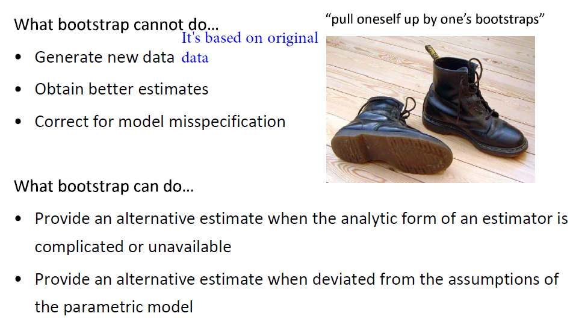

# 4 Practical

Bootstrap method for non-normal estimate The weight and height of 100 healthy men are stored in the file “BMI.csv”, which can be loaded via bmi <- read.csv(“YOUR PATH/BMI.csv”) It can be assumed that height is normally distributed. However, the variable at interest (BMI) and weight are not normally distributed. [BMI = weight (kg) / height2 (m2)].

```r
bmi <- read.csv ("Data/BMI.csv")
bmi$BMI <- with(bmi, weight/height^2)
```

## a) Density plot

1. Calculate the BMI of the 100 healthy men and plot the distribution of weight, height and BMI in a panel.

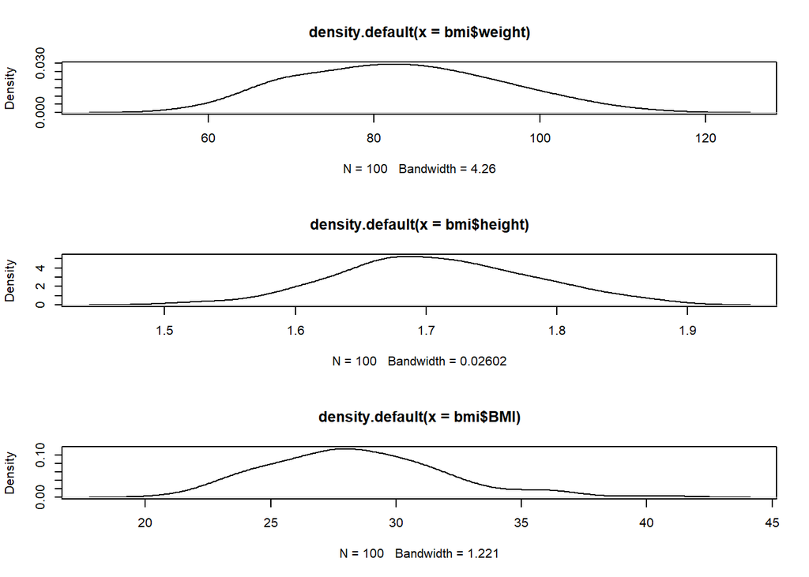

```r
par(mfrow=c(3,1))
plot(density(bmi$weight))
plot(density(bmi$height))
plot(density(bmi$BMI))
```

## b) Test normality

2. Assess the normality of the three variables (weight, height and BMI).  
   Google search: (test normality, R) or ??normality => Shapiro.Wilk Normality test null hupothesis = normal distribution

```r
shapiro.test(bmi$weight)
shapiro.test(bmi$height)
shapiro.test(bmi$BMI)
# p-val = 0.53, 0.81, 0.04 respectively => BMI is not normal distribution
```

```
##
##  Shapiro-Wilk normality test
##
## data:  bmi$weight
## W = 0.98835, p-value = 0.534
##
##
##  Shapiro-Wilk normality test
##
## data:  bmi$height
## W = 0.99189, p-value = 0.8133
##
##
##  Shapiro-Wilk normality test
##
## data:  bmi$BMI
## W = 0.9729, p-value = 0.03699
```

## c) Boostrap calculation

3. Calculate the bootstrap estimate of the mean and the corresponding 95% percentile bootstrap confidence interval for BMI, from 1000 bootstrap samples

```r
## Teacher solution
b.bmi <- rep(NA, 1000)
for (i in 1:1000){
  bmi.new <- bmi[sample(1:100, 100, replace=T),]
  b.bmi[i] <- mean(bmi.new$weight/bmi.new$height^2)
}
mean(b.bmi)
quantile(b.bmi, c(0.025, 0.975))
## My solution
boot1 <- function (m, original.data){
 bmib <- rep (NA, m)
 for (i in 1:m){
  newdata <- original.data[sample(1:100, 100, replace=TRUE),]
  bmib[i] <- with(newdata, weight/height^2)
 }
 return(bmib)
}
bmib <- boot1(1000, original.data=bmi)
mean(bmib)
quantile(bmib, c(0.025, 0.975))
```

```
## [1] 28.40767
##     2.5%    97.5%
## 27.77530 29.04357
## [1] 28.24509
##     2.5%    97.5%
## 22.97437 36.46267
```

## d) Bootstrap calculation with package

4. Obtained the 95% BCa confidence interval for BMI.

```r
library(boot)
bmi.f <- function(data, indices){
  bmi.new <- bmi[indices,]
  return(mean(bmi.new$BMI))
}
bmi.b.out <- boot(data=bmi, statistic=bmi.f, R=1000)
boot.ci(bmi.b.out)
```

```
## BOOTSTRAP CONFIDENCE INTERVAL CALCULATIONS
## Based on 1000 bootstrap replicates
##
## CALL :
## boot.ci(boot.out = bmi.b.out)
##
## Intervals :
## Level      Normal              Basic
## 95%   (27.70, 29.11 )   (27.67, 29.09 )
##
## Level     Percentile            BCa
## 95%   (27.74, 29.16 )   (27.74, 29.17 )
## Calculations and Intervals on Original Scale
```